# 03.3: Docker Compose

[figure not shown]

# 2 / 8: Docker Compose

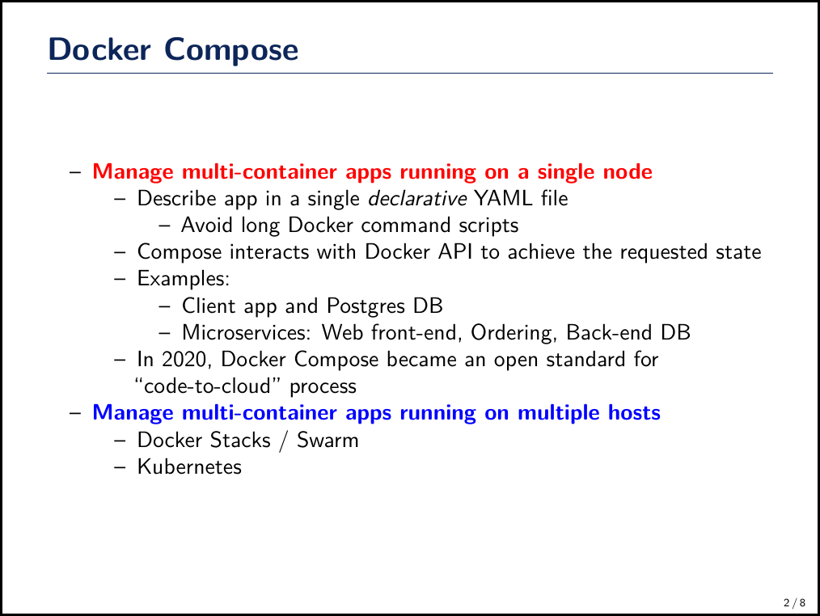

- **Docker Compose**
  - *Manage multi-container apps running on a single node*
    - Docker Compose is a tool that helps you manage applications that consist of multiple containers on a single machine. Instead of running each container with a long list of commands, you can use a single YAML file to describe the entire application setup. This makes it easier to manage and understand.
    - The YAML file is *declarative*, meaning you specify what you want, and Docker Compose takes care of making it happen by interacting with the Docker API. This simplifies the process and reduces the chance of errors.
    - Some common examples of applications you might manage with Docker Compose include a client application that connects to a Postgres database or a set of microservices like a web front-end, an ordering service, and a back-end database.
    - In 2020, Docker Compose became an open standard, which means it is widely accepted and used for moving code from development to production environments, often referred to as the “code-to-cloud” process.
- *Manage multi-container apps running on multiple hosts*
  - When you need to manage applications that run across multiple machines, you can use tools like Docker Stacks or Docker Swarm. These tools help coordinate and manage containers across different hosts.
  - Kubernetes is another popular tool for managing multi-container applications across multiple hosts. It provides advanced features for scaling, managing, and deploying applications in a distributed environment.

# 3 / 8: Docker Compose: Tutorial Example

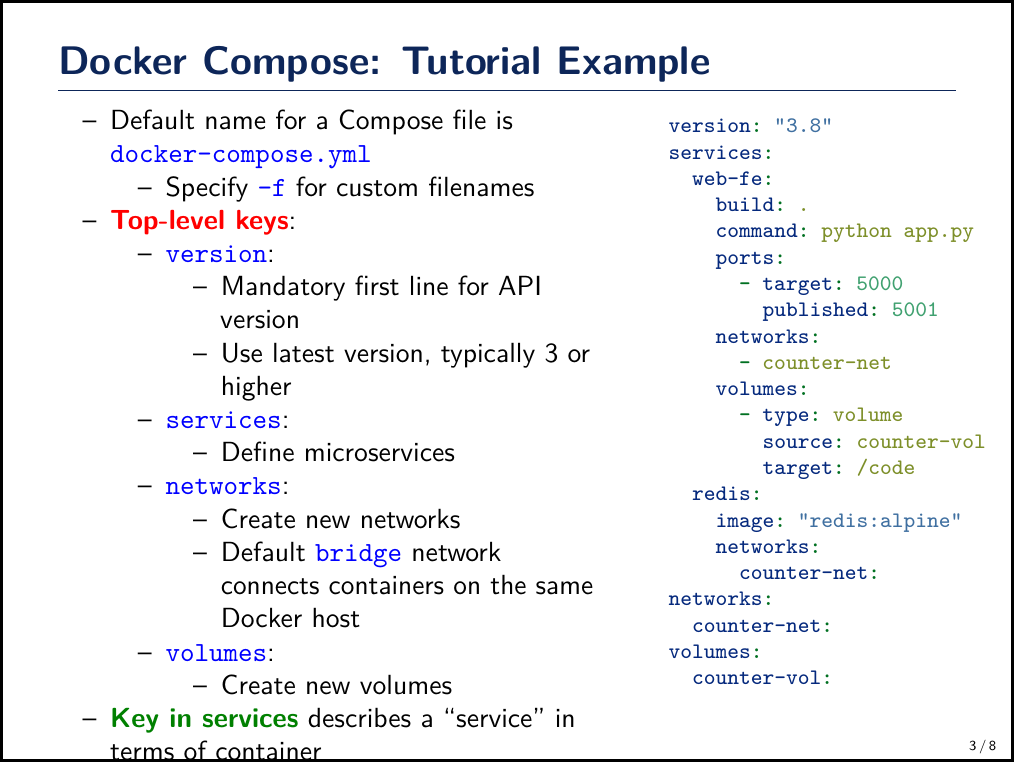

- **Default name for a Compose file is `docker-compose.yml`**
  - This is the standard file name Docker Compose looks for by default. If your file has a different name, you need to specify it using the `-f` option when running Docker Compose commands.
- **Top-level keys**:
  - **`version`**:
    - This key specifies the version of the Docker Compose file format. It’s important to use the latest version, usually 3 or higher, to ensure compatibility with the latest features.
  - **`services`**:
    - This section is where you define the different microservices that make up your application. Each service corresponds to a container.
  - **`networks`**:
    - Networks allow containers to communicate with each other. By default, Docker uses a `bridge` network, which connects containers on the same host.
  - **`volumes`**:
    - Volumes are used to persist data generated by and used by Docker containers. They are especially useful for keeping data even when containers are removed.
- **Key in services** describes a “service” in terms of a container
  - **Inner keys** specify parameters that are similar to those used in the `docker run` command. These include settings like the image to use, commands to run, ports to expose, and more.

The YAML example on the right illustrates a simple setup with two services: a web frontend (`web-fe`) and a Redis database. The `web-fe` service is built from the current directory, runs a Python application, and exposes port 5001. It also uses a custom network (`counter-net`) and a volume (`counter-vol`) to store code. The `redis` service uses a lightweight Redis image and connects to the same network, allowing it to communicate with the `web-fe` service.

# 4 / 8: Docker Compose: Commands

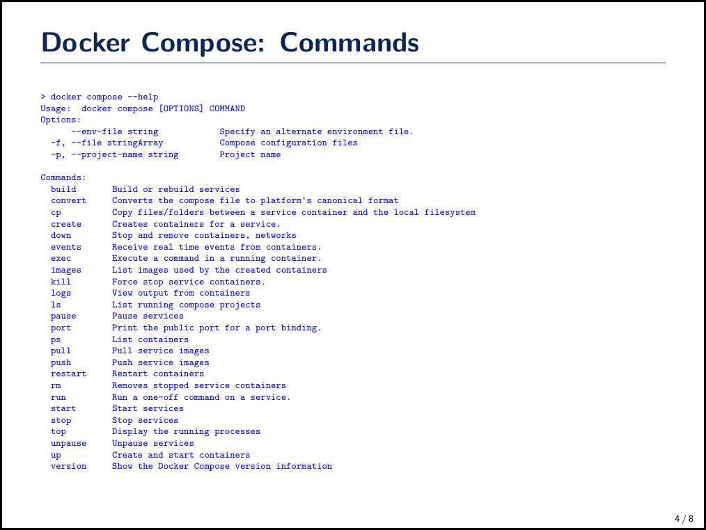

- **Docker Compose Overview**: Docker Compose is a tool used for defining and running multi-container Docker applications. It allows you to manage the lifecycle of your application services using a simple configuration file.
- **Usage and Options**:
  - *Usage*: The command `docker compose [OPTIONS] COMMAND` is the basic structure for using Docker Compose. You specify options and a command to perform specific tasks.
  - **–env-file**: This option lets you specify an alternate environment file, which is useful for managing different configurations for different environments (e.g., development, testing, production).
  - **-f, –file**: Allows you to specify one or more Compose configuration files. This is helpful when you have multiple configuration files for different setups.
  - **-p, –project-name**: Sets a custom project name, which is useful for organizing and managing multiple projects.
- **Common Commands**:
  - **build**: Builds or rebuilds services defined in the Compose file. This is often the first step to ensure all services are up-to-date.
  - **up**: Creates and starts containers as defined in the Compose file. This is the primary command to launch your application.
  - **down**: Stops and removes containers, networks, and other resources created by `up`. Use this to clean up your environment.
  - **logs**: Displays the output from containers, which is crucial for debugging and monitoring.
  - **ps**: Lists all containers managed by the current Compose project, providing a quick overview of what’s running.
  - **exec**: Executes a command inside a running container, useful for debugging or running maintenance tasks.
  - **restart**: Restarts containers, which can be necessary after configuration changes or updates.
  - **version**: Displays the version information of Docker Compose, ensuring compatibility and troubleshooting.
- **Context and Importance**:
  - Docker Compose simplifies the management of complex applications by allowing you to define services, networks, and volumes in a single file.
  - It is particularly useful in development and testing environments where you need to quickly spin up and tear down services.
  - Understanding these commands and options is crucial for effectively using Docker Compose to manage containerized applications.

# 5 / 8: Docker Compose: Commands

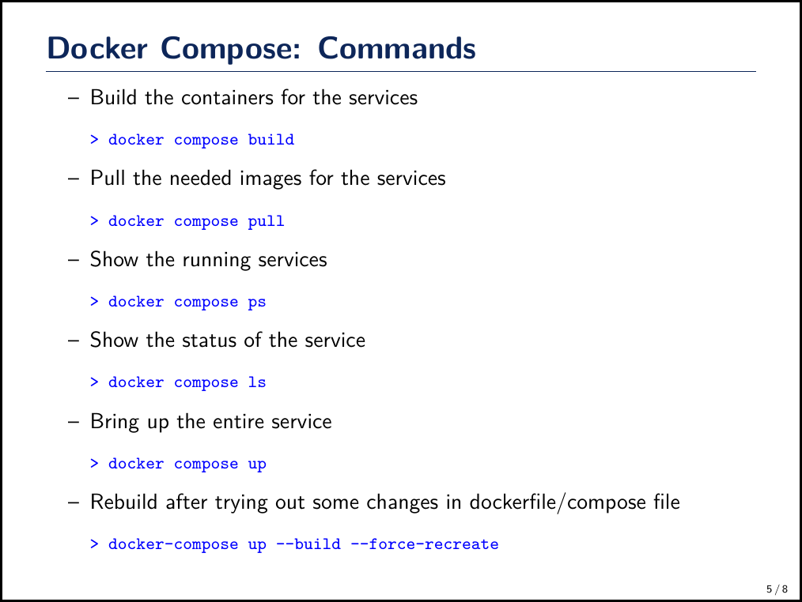

- **Build the containers for the services**
  - This command, `docker compose build`, is used to create Docker images based on the instructions provided in the Dockerfile. It compiles the necessary components and dependencies into a container image. This is the first step in setting up your services, ensuring that everything is packaged correctly before running.
- **Pull the needed images for the services**
  - The `docker compose pull` command fetches the latest versions of the images specified in your Docker Compose file from a container registry. This is useful when you want to ensure that you have the most up-to-date images before starting your services.
- **Show the running services**
  - By using `docker compose ps`, you can view a list of all the services that are currently running. This command provides a quick overview of the status and health of your containers, helping you monitor your application’s components.
- **Show the status of the service**
  - The `docker compose ls` command lists all the Docker Compose projects on your system, showing their current status. This is helpful for managing multiple projects and understanding which ones are active or need attention.
- **Bring up the entire service**
  - With `docker compose up`, you can start all the services defined in your Docker Compose file. This command initializes and runs the containers, making your application available for use. It’s a straightforward way to launch your entire stack with a single command.
- **Rebuild after trying out some changes in dockerfile/compose file**
  - The command `docker-compose up --build --force-recreate` is used when you have made changes to your Dockerfile or Compose file and need to apply those changes. It rebuilds the images and recreates the containers, ensuring that your updates are reflected in the running services. This is crucial for testing and deploying new features or fixes.

# 6 / 8: Docker Compose: Commands

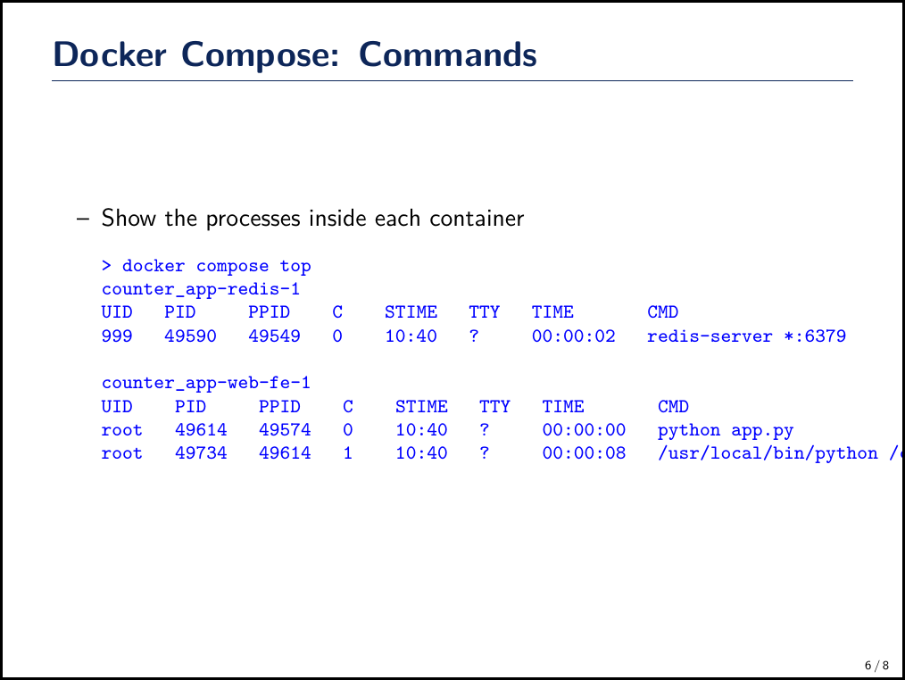

- **Show the processes inside each container**: This command is useful when you want to see what processes are running inside your Docker containers. It provides a snapshot of the current state of each container’s processes, similar to the `top` command in Linux, but specifically for Docker containers.
- **Command**: `docker compose top` is the command used to display the processes. This command is part of Docker Compose, a tool for defining and running multi-container Docker applications. It helps you manage and monitor the processes within your containers.
- **Example Output**: The output shows two containers, `counter_app-redis-1` and `counter_app-web-fe-1`. For each container, it lists details like **UID** (User ID), **PID** (Process ID), **PPID** (Parent Process ID), **C** (CPU usage), **STIME** (Start Time), **TTY** (Terminal Type), **TIME** (CPU Time), and **CMD** (Command being executed).
- **Understanding the Output**:
  - For `counter_app-redis-1`, the process is `redis-server *:6379`, indicating that a Redis server is running.
  - For `counter_app-web-fe-1`, there are two processes: `python app.py` and `/usr/local/bin/python /code/app.py`, showing that a Python application is running, likely a web application.
- **Importance**: This command is particularly useful for debugging and monitoring purposes. It allows you to verify that the expected processes are running and helps in diagnosing issues related to resource usage or unexpected behavior within your containers.

# 7 / 8: Docker Compose: Commands

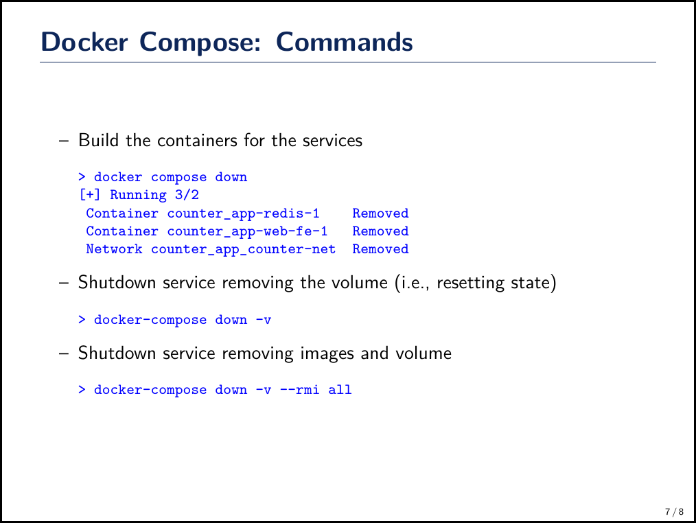

# 8 / 8: Docker Compose: Tutorial

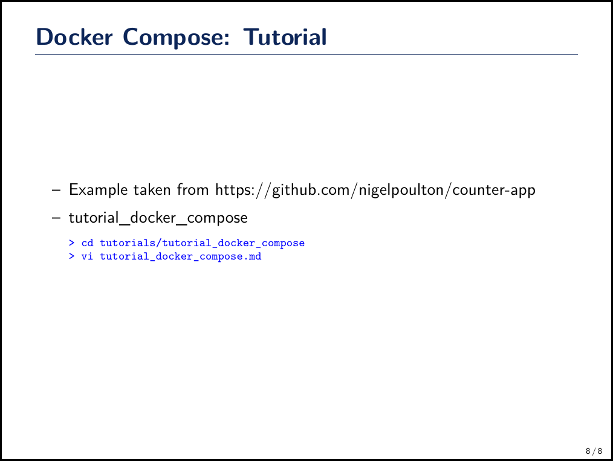

  - ```bash
    > cd tutorials/tutorial_docker_compose
    > vi tutorial_docker_compose.md
    ```

  - These commands are meant to guide you through accessing and editing the tutorial files. The first command, `cd`, changes the directory to where the tutorial files are located. The second command, `vi`, opens a text editor to view or edit the `tutorial_docker_compose.md` file. This file likely contains detailed instructions or explanations related to the Docker Compose tutorial.